# STAT R Lab1

Chen

#### 1. 安裝 R 和 RStudio

R Link

RStudio Link

下載完後，點開執行檔，不用多做設定，一直下一步即可安裝完成，如果 Rstudio 安裝完打不開，可以到控制台將其刪除，重新安裝。

#### 2. 加減乘除四則運算

在 R 裡面，運算規則與一般的數學相同，先乘除後加減，一般會用到的運算規則相信各位同學都足夠熟悉。

```r
1 + 2
```

```
## [1] 3
```

```r
3 / 2
```

```
## [1] 1.5
```

```r
3 - 5
```

```
## [1] -2
```

```r
2 * 2
```

```
## [1] 4
```

#### 3. 變數與賦值

如下面舉例，Var 就稱作變數，而將123指向Var的這個過程叫做賦值。

此箭頭符號`<-`可用快捷鍵`Ctrl + Alt + i`完成。

```r
Var <- 123
```

而賦值的過程除了用箭頭代替，亦可以使用`=`來完成。

```r
Var2 = 321
```

經過賦值，所以Var、Var2各代表什麼？

```r
Var
```

```
## [1] 123
```

```r
Var2
```

```
## [1] 321
```

#### 4. 字元、數值、整數

判斷某個變數的型別，可以使用`typeof()`指令。

字元就是以`""`符號所括之內容，在程式語言裡面為表示文字的型別。

```r
string = "霹靂卡霹靂拉拉波波莉娜貝貝魯多"
typeof(string)
```

```
## [1] "character"
```

數值（numeric），雙倍精準度數值，簡單來形容就是double

```r
num = 59.4
typeof(num)
```

```
## [1] "double"
```

```r
num2 = 59
typeof(num2)
```

```
## [1] "double"
```

整數，沒有小數位的數值，通常要表示整數會在數字後面加上一個L來表示。

```r
x = 23L
typeof(x)
```

```
## [1] "integer"
```

#### 5. 向量、矩陣、list、dataframe

使用`c`函數來製作向量，其中`1:5`表示數字1~5。

```r
c(1:5)
```

```
## [1] 1 2 3 4 5
```

向量除了裝數字，還可以裝文字，但是要注意，向量裡面有多種不同型別的元素，會被強制轉成同一種型別，轉換的原則有需要用到再查。

```r
vec = c(1, 2, 4, "mat", 3.3, "stat")
vec
```

```
## [1] "1"    "2"    "4"    "mat"  "3.3"  "stat"
```

```r
typeof(vec)
```

```
## [1] "character"
```

矩陣可以拿來儲存多行多列的資料，可以拿來做矩陣運算，此外，沒有column name和row name

```r
mat = matrix(1:8, ncol = 4, nrow = 2, byrow = TRUE)
mat
```

```
##      [,1] [,2] [,3] [,4]
## [1,]    1    2    3    4
## [2,]    5    6    7    8
```

```r
typeof(mat)
```

```
## [1] "integer"
```

list與向量類似，但區別在於，它可以放入多種不同型別的元素。

```r
x = list(1, 2, 3.5, "matrix", 1L, TRUE)
x
```

```
## [[1]]
## [1] 1
##
## [[2]]
## [1] 2
##
## [[3]]
## [1] 3.5
##
## [[4]]
## [1] "matrix"
##
## [[5]]
## [1] 1
##
## [[6]]
## [1] TRUE
```

```r
typeof(x)
```

```
## [1] "list"
```

dataframe資料匡，大部分讀取進來的資料都會是資料匡的形式，與矩陣不同在於，它會有column name以及row name

```r
df = data.frame("性別" = c("F", "M", "F", "F"),
                "身高" = c(180, 192, 155, 140))
df
```

```
##   性別 身高
## 1    F  180
## 2    M  192
## 3    F  155
## 4    F  140
```

```r
typeof(df)
```

```
## [1] "list"
```

#### 6. 畫圖

下面是本次上課的資料，請同學先run一次才會有資料。

```r
data = data.frame("Sex" = c(sample(c("F", "M"), size = 20, replace = T, p = c(0.5, 0.5))),
                  "Height" = c(rnorm(20, 175, 2)),
                  "Weight" = c(rnorm(20, 60, 1)),
                  "Age" = c(sample(c(10:40), replace = T, 20)))
data
```

```
##    Sex   Height   Weight Age
## 1    F 176.7027 60.57297  26
## 2    F 176.6908 61.64171  38
## 3    M 170.1272 60.75610  13
## 4    M 177.2204 61.61136  34
## 5    F 175.7302 61.61628  28
## 6    F 174.9678 60.86565  33
## 7    M 174.1010 60.31570  27
## 8    M 175.1778 60.43124  30
## 9    M 173.5732 60.44384  35
## 10   F 174.7834 61.04024  37
## 11   F 175.6899 58.63053  24
## 12   M 172.9425 60.23654  19
## 13   F 177.6516 61.33559  23
## 14   M 176.9418 59.21580  23
## 15   M 174.0534 58.82024  28
## 16   M 175.2590 59.16272  19
## 17   M 173.6747 58.75823  18
## 18   F 175.4876 58.04503  19
## 19   M 172.2470 59.59537  17
## 20   M 172.9320 59.17529  11
```

今天先教R內建的繪圖函數，`plot`以及`hist`。

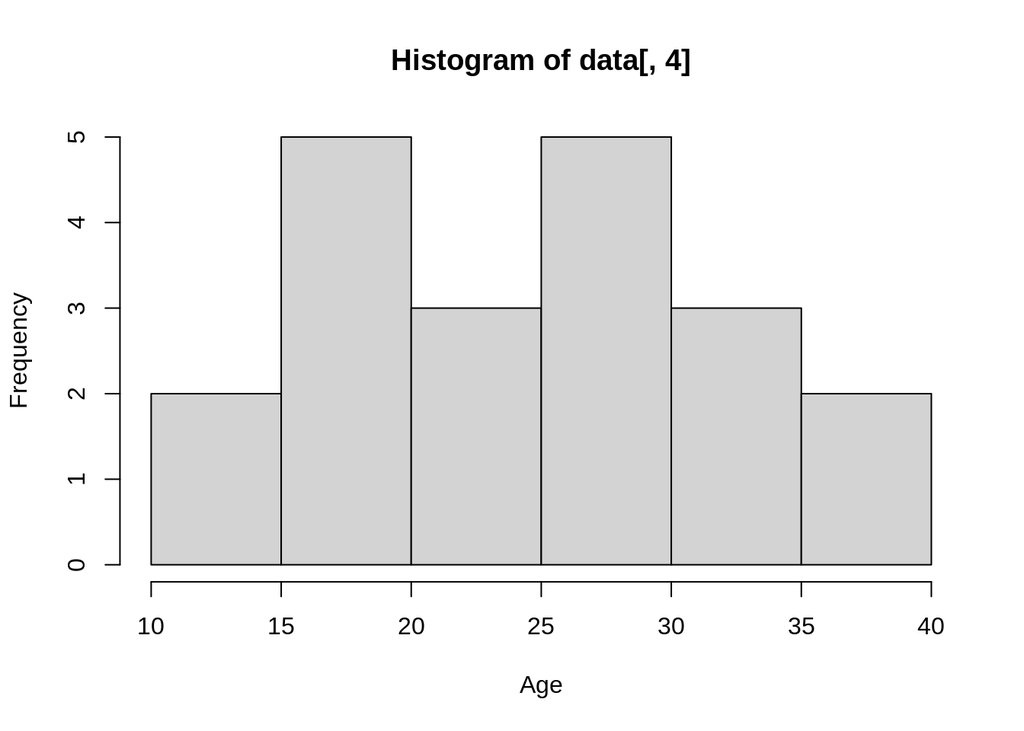

```r
hist(data[, 4], xlab = "Age")
```

或是我想要觀察會不會有身高越高的人體重越重的情況，這時候就需要用到散步圖。

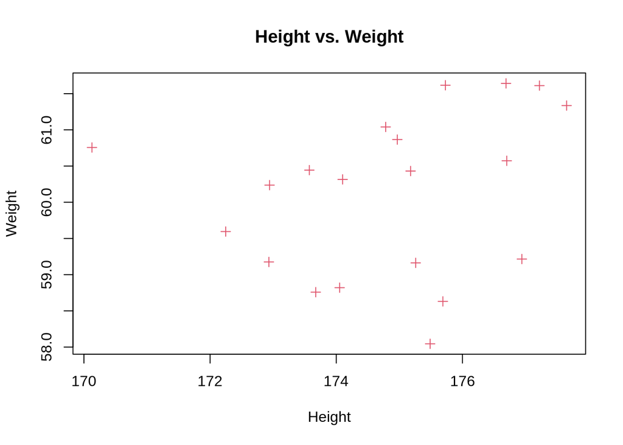

```r
plot(data[, 2], data[, 3], xlab = 'Height', ylab = "Weight", main = "Height vs. Weight", col = 2, pch = 3)
```

或是有一組資料，每年的生產量。

```r
pro = data.frame("Year" = c(2001:2012), 'Yield' = c(rnorm(12, 123, 2)))
pro
```

```
##    Year    Yield
## 1  2001 125.2645
## 2  2002 120.2908
## 3  2003 121.2203
## 4  2004 122.9873
## 5  2005 123.3135
## 6  2006 124.6752
## 7  2007 118.7145
## 8  2008 119.4516
## 9  2009 123.1940
## 10 2010 123.1164
## 11 2011 123.0054
## 12 2012 124.2590
```

畫一個折線圖來看看生產量的趨勢。

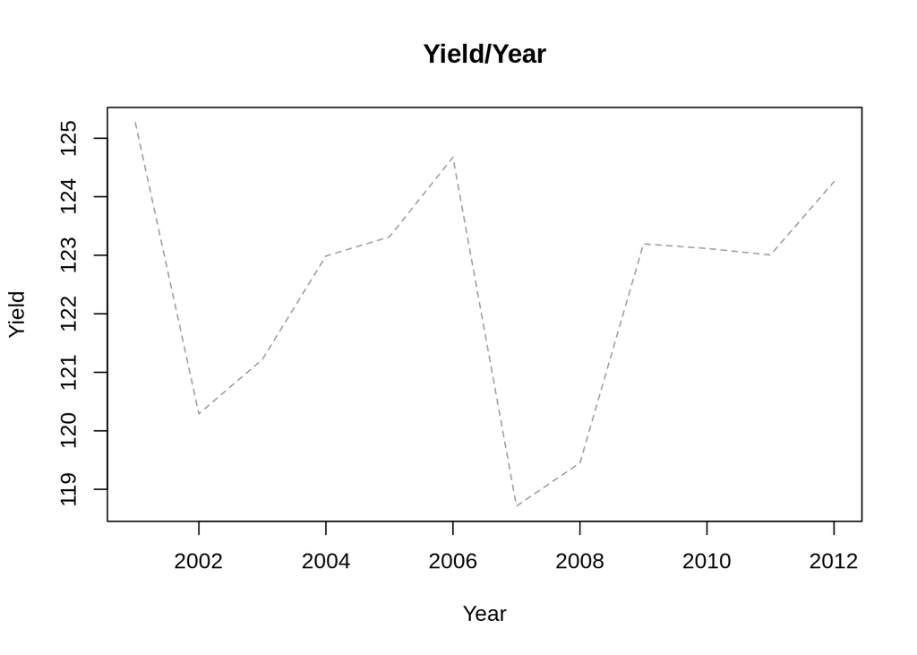

```r
plot(pro[, 1], pro[, 2], "l", lty = 2, col = 8, xlab = "Year", ylab = "Yield", main = "Yield/Year")
```

#### 作業

利用R內建的資料集`cars`來作圖，做同學認為覺得適合的圖

請先運行下面指令，以獲得資料集

```r
cars
```

```
##    speed dist
## 1      4    2
## 2      4   10
## 3      7    4
## 4      7   22
## 5      8   16
## 6      9   10
## 7     10   18
## 8     10   26
## 9     10   34
## 10    11   17
## 11    11   28
## 12    12   14
## 13    12   20
## 14    12   24
```

[output cut: 36 more lines]

**請注意，圖一定要有圖名，x, y軸個別代表什麼變量要標注上去，此外請改動顏色或是圖標、線條的樣式**